# R Markdown Schedule

Nick Hatzenbeller

February 8, 2021

# Class Schedule

### PHIL 119: Ethical Leadership

I am currently enrolled in a Philosophy course in which we learn about ethical leadership and what attributes are needed to be an ethical leader. This course is extremely interesting to me because I’ve always wanted to learn a bit more about philosophy and the works of famous philosophers like Plato and Aristotle. I find it very cool to analyze the thinking of these individuals who lived on earth many years before me. It is amazing to see how they think and be able to connect it with the way that humans think and interact today. It really shows me that even though humans have changed a lot since ancient Greek times, there are still many things that are similar. Overall, we are just getting started in the class but I have already learned a lot by reading Plato’s and Aristotle’s work (Written by Aristotle: https://www.stmarys-ca.edu/sites/default/files/attachments/files/Nicomachean_Ethics_0.pdf). I hope to continue to expand my knowledge into a topic that I was unfamiliar with as the semester goes on. Additionally, being a data science major, I am used to classes that revolve around technology and modern topics, so learning about past philosophers is a nice break.

[figure not shown]

Photo of Plato and Aristotle, two of the most well known philosophers

# Hobbies, etc

### Penn State Men’s Club Soccer

The first club that I joined at Penn State was the Penn State Men’s Club Soccer Team. I joined the club soccer team my freshman year. I have played soccer since I was around 5 years old, so going into college I knew that I wanted to join a competitive soccer team so that I could continue playing one of my favorite sports at a high level. It was extremely hard to get chosen for the squad, as there were about 400 kids trying out and they only had 10 roster spots open. I knew that I needed to play hard every tryout and do something to get noticed so that I could secure a spot. I was extremely happy when I found out I made the team and I knew all my hard work paid off. Joining the club team was a great choice as it helped me make friends during my first semester and it also helped keep me in shape since we practiced four times a week and had games on the weekend. Unfortunately, due to COVID-19, we have not been able to have a real season or hold practices, so I haven’t been able to play soccer at a high level as much as I’d like to this semester. However, next year, I am hoping that everything returns back to normal so that I can continue to play the game I love. (Org Central Website: https://orgcentral.psu.edu/organization/soccer--men).

[figure not shown]

Photo of me in my first club soccer game

### Working Out at the Gym

One big hobby of mine is staying in shape. I really enjoy playing sports to stay in shape but one of the main ways I stay in shape is working out at the gym. I try to lift weights and use machines five days a week while at school, taking the weekend off. I started working out my junior year of high school, using weights here and there. I realized that I was a bit unhealthy so senior year of high school is when I really changed my eating habits and also began working out much more seriously. In college, I try to stay very fit and active, as I know that there is a common conception that people gain weight in college due to not playing sports anymore and eating a lot. So I make sure that I incorporate the gym into my schedule as often as possible. This semester, I have been going to Planet Fitness (Planet Fitness State College Website: https://www.planetfitness.com/gyms/state-college-pa) with my friend. We do a workout together each day in the afternoon and try to keep each other motivated to stay fit. After I workout, I usually feel very good about myself and it makes me feel healthy and accomplished. I plan to continue to workout all throughout college as well as into my life after college. It is a hobby of mine that I can see myself participating in for a long time. Obviously, there will be times where I will be very busy, so I may have to modify my workout routine. Though, I love to workout and feel healthy.

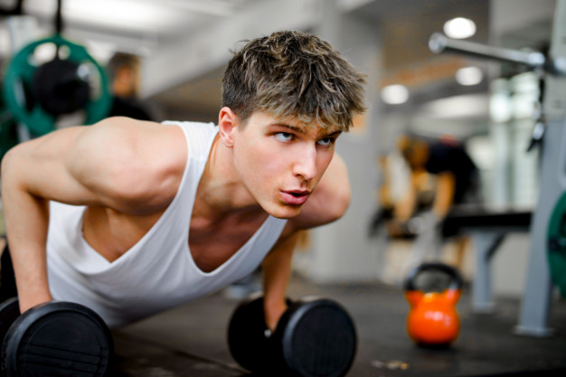

Man working out in the gym